# Comparacion de Tarifas de Unidades de Bioinformatica/Bioestadistica

Alex Sanchez y Miriam Mota

Unitat d’Estadística i Bioinformàtica. Vall d’Hebron Institut de Recerca

# Introducción

Este documento presenta una primera aproximación a una comparación de tarifas de unidades de bioinformática y bioestadística.

Esta comparativa se inició en Barcelona, en el Vall d’Hebrón Institut de Recerca (VHIR) y se ha ido extendiendo -bajo el impulso de TransBionet- a otros centros catalanes y españoles, lo que explica el reparto desigual entre comunidades. La muestra de unidades no es aleatoria sino oportunista: se ha recogido los datos a los que se ha tenido acceso. Ahora bien, como el número total de unidades no es muy alto es probable que se pueda considerar relativamente representativa.

En esta primera aproximación nos limitaremos a explorar la tabla de datos recogida con el objetivo de mostrar como se distribuyen las tarifas según el tipo de cliente o la tipología de la unidad. Los clientes se clasifican como “internos”, “públicos” o “privados” en la mayoría de unidades, por lo que se ha adoptado esta denominación

## Los datos y el código para el análisis

Los datos para el análisis se encuentran en una hoja de `googlesheets` a la que se puede acceder y modificar por su enlace por lo que, de momento se trabajará con una versión descargada del sitio.

El código para el análisis se encuentra disponible en github en la dirección: https://github.com/uebvhir/ComparacionTarifas

Se utilizan algunas librerías “internas” de la UEB en el VHIR pero los análisis se pueden realizar fácilmente con cuatro funciones básicas de R o python.

## Lectura y recodificación de los datos

Previo al análisis se han recodificado algunos datos (por ejemplo pasar a factores algunas variables carácter, y recodificar la variable “Pers”) y hecho algo de limpieza para evitar categorias erroneamente distintas (unificar los valores SI y Si como respuestas) )

Summary Data. N variables: 9. N observaciones: 32 Max level: 7. Max NA: 80%

|  | Variable | Type | [Min,Max] or Levels | Valid cases, n (%) Missings, n (%) |
| --- | --- | --- | --- | --- |
| ID_centro | ID_centro | character | - | 32 (100%) 0 (0%) |
| LOC | LOC | character | - | 32 (100%) 0 (0%) |
| Tipo | Tipo | character | - | 31 (96.875%) 1 (3.125%) |
| TransBioNet | TransBioNet | character | - | 31 (96.875%) 1 (3.125%) |
| Criterio | Criterio | character | - | 27 (84.375%) 5 (15.625%) |
| Pers. | Pers. | numeric | [1, 7] | 30 (93.75%) 2 (6.25%) |
| Interna | Interna | character | - | 19 (59.375%) 13 (40.625%) |
| Publica | Publica | character | - | 19 (59.375%) 13 (40.625%) |
| Privada | Privada | character | - | 18 (56.25%) 14 (43.75%) |

# Resumen de los datos

## Centros cuyas unidades se han incluído en el estudio

| ID | CENTRO |
| --- | --- |
| VHIR | Institut de Recerca Vall d’Hebron (VHIR) |
| IBSP | Institut de Recerca de l’Hospital de la Santa Creu i Sant Pau |
| HSJD | Hospital Sant Joan de Deu |
| HSJD | Hospital Sant Joan de Deu |
| IMIM | IMIM |
| IMIM | IMIM |
| IDBE | IDIBELL |
| IDBE | IDIBELL |
| IDBA | IDIBAPS |
| IGTP | Institut Germans Trias i Pujol (IGTP) |
| CRG | Centre de Regulació Genòmica (CRG) |
| CRG | NA |
| IRBL | Institut de Recerca Biomèdica de Lleida (IRB Lleida) |
| SEA | Universitat Autònoma de Barcelona (UAB) |
| UAB | Universitat Autònoma de Barcelona (UAB) |
| IDIS | Instituto de Investigación Sanitaria de Santiago de Compostela (IDIS) |
| IRyC | Instituto Ramon y Cajal de Investigación Sanitaria (IRyCIS) |
| IRyC | Instituto Ramon y Cajal de Investigación Sanitaria (IRyCIS) |
| IACS | Instituto Aragonés de Ciencias de la Salud (IACS) |
| INCLIVA | Instituto de Investigación Sanitaria INCLIVA |
| IMIB | Instituto Murciano de Investigación Biosanitaria (IMIB) |
| IMDEA | IMDEA Alimentación |
| IdISBa | IdISBa Institut d’Investigació Sanitària Illes Balears |
| IISFJD | IIS-Fundación Jiménez Díaz |
| GENYO | Centro de Genómica e Investigación Oncológica (GENYO) |
| IISGM | Instituto de Investigación Sanitaria Gregorio Marañón (IiSGM) |
| CIPF | Centro de Investigación Príncipe Felipe |
| IRBB | IRB Barcelona, BIST |
| IBIMA | Instituto de Investigacion Biomedica de Malaga (IBIMA) |
| CIC-IBMCC | Unidad de Bioinformática (CiC-IBMCC, CSIC/USAL) |
| ISSBioDonostia | Computational Biomedicine Data Analysis Platform (ISS BioDonostia) Computational Biology and Systems Biomedicine Research Group |
| IHUP | Instituto de Investigación Sanitaria Hospital Universitario de la Princesa |

## Resumenes numericos

La tabla siguiente resumen algunas de las variables recogidas. Aunque parece claro que puede interesar comparar como se distribuyen las tarifas por comunidades, tipología de centros o tipos de unidades, esta información no parece disponible o bien representada salvo para el tipo de unidad.

Summary statistics table

| variable | levels | ALL | n |
| --- | --- | --- | --- |
| loc<sub>1</sub> | AND | 2 (6.2%) [0.8; 20.8] | 32 |
|  | ARA | 1 (3.1%) [0.1; 16.2] |  |
|  | BAL | 1 (3.1%) [0.1; 16.2] |  |
|  | CAT | 16 (50%) [31.9; 68.1] |  |
|  | CYL | 1 (3.1%) [0.1; 16.2] |  |
|  | GAL | 1 (3.1%) [0.1; 16.2] |  |
|  | MAD | 6 (18.8%) [7.2; 36.4] |  |
|  | MUR | 1 (3.1%) [0.1; 16.2] |  |
|  | PVA | 1 (3.1%) [0.1; 16.2] |  |
|  | VAL | 2 (6.2%) [0.8; 20.8] |  |
| tipo<sub>1</sub> | BIOEST | 7 (22.6%) [9.6; 41.1] | 31 |
|  | BIOINF | 11 (35.5%) [19.2; 54.6] |  |
|  | BIOINF_BIOEST | 13 (41.9%) [24.5; 60.9] |  |
| trans_bio_net<sub>1</sub> | NO | 12 (38.7%) [21.8; 57.8] | 31 |
|  | SI | 19 (61.3%) [42.2; 78.2] |  |
| criterio<sub>1</sub> | Por horas | 13 (48.1%) [28.7; 68.1] | 27 |
|  | Por servicio, muestras y por horas | 4 (14.8%) [4.2; 33.7] |  |
|  | Por servicios | 1 (3.7%) [0.1; 19] |  |
|  | Por servicios y horas | 4 (14.8%) [4.2; 33.7] |  |
|  | Por tandas | 1 (3.7%) [0.1; 19] |  |
|  | Por tandas y por muestra adicional | 1 (3.7%) [0.1; 19] |  |
|  | Por tandas y por presupuesto | 1 (3.7%) [0.1; 19] |  |
|  | Presupuesto | 2 (7.4%) [0.9; 24.3] |  |
| pers<sub>2</sub> |  | 30 3 (1.7) CI[2.3;3.6] 2.5 [2,4] | 30 |
| interna<sub>2</sub> |  | 19 28.9 (12.2) CI[23;34.8] 28 [20.4,34.9] | 19 |
| publica<sub>2</sub> |  | 19 44.9 (14.7) CI[37.8;51.9] 43.5 [34.5,57] | 19 |
| privada<sub>2</sub> |  | 17 56.9 (21.1) CI[46;67.7] 56 [44.1,67] | 17 |
| unit_size<sub>1</sub> | 1-Ssingle | 6 (20%) [7.7; 38.6] | 30 |
|  | 2-Small | 14 (46.7%) [28.3; 65.7] |  |
|  | 3-Medium | 7 (23.3%) [9.9; 42.3] |  |
|  | 4-Big | 3 (10%) [2.1; 26.5] |  |

* 1: n(%) [Exact CI]  
† 2: N mean(sd) [CI95% mean] median[IQR]

## Visualización de las variables

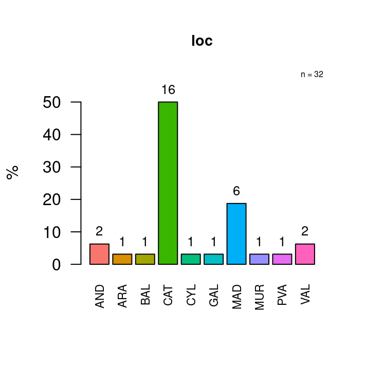

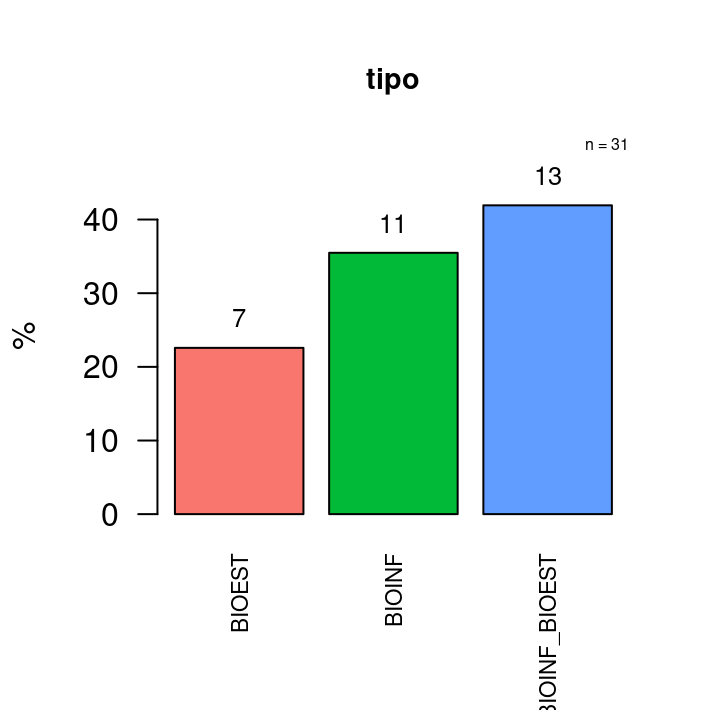

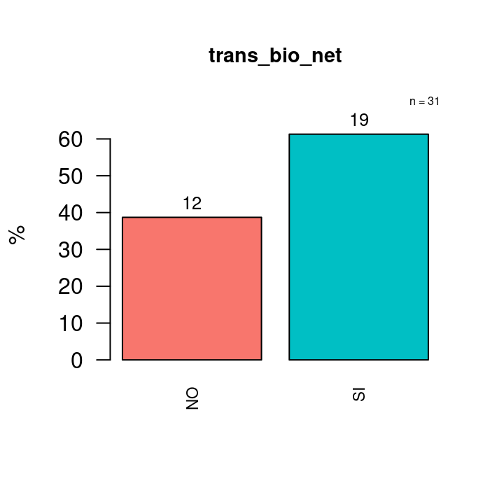

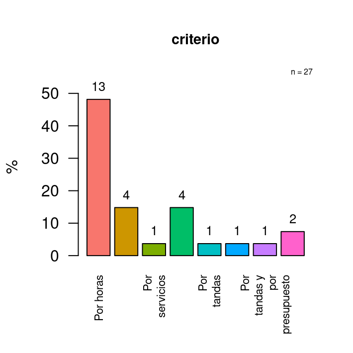

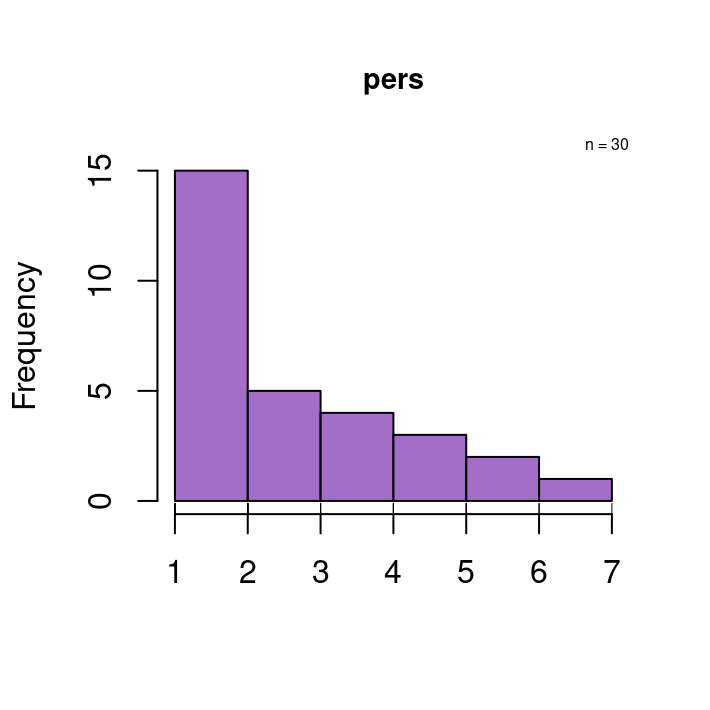

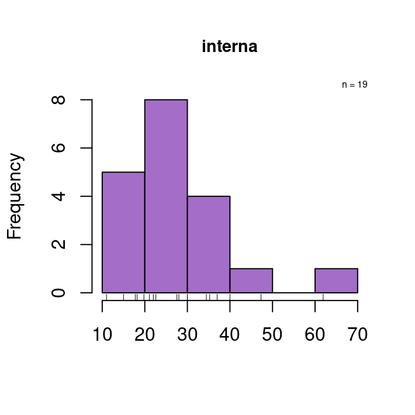

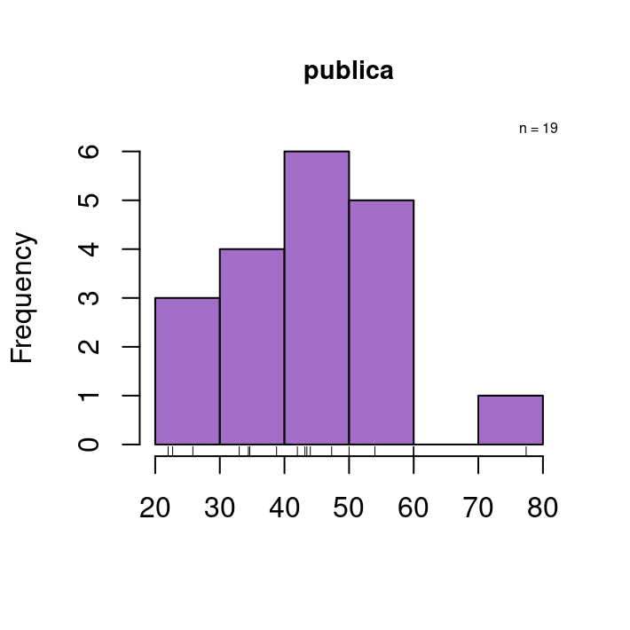

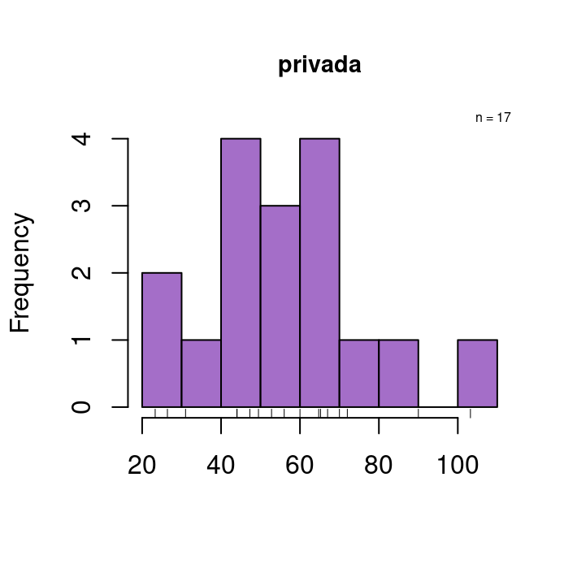

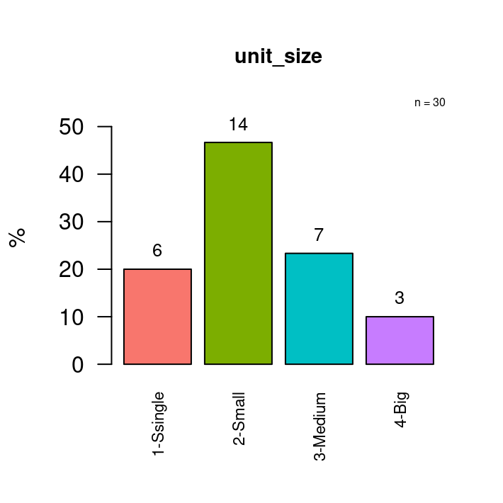

# Comparación de tarifas

## Tarifas por tipo de usuario

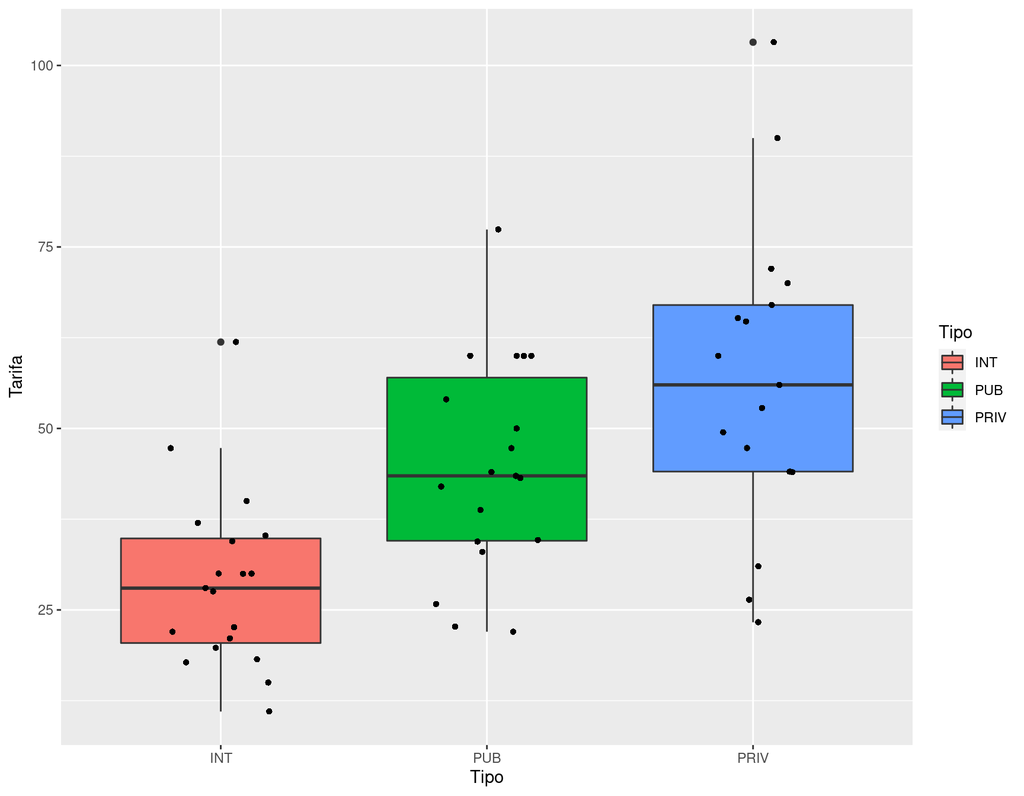

## Tarifas por centro en que se aplican y tipo de usuario

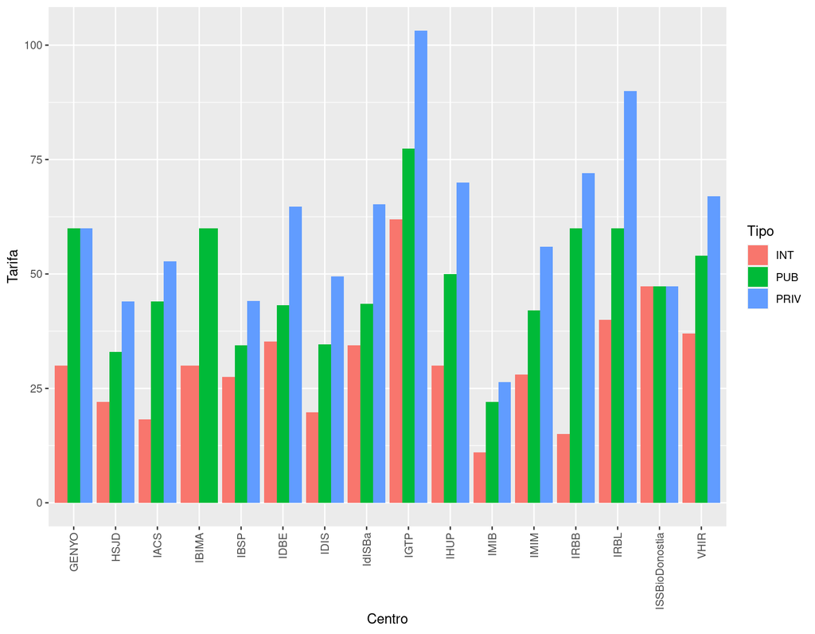

## Tarifas por tipo de usuario y tamaño de la unidad

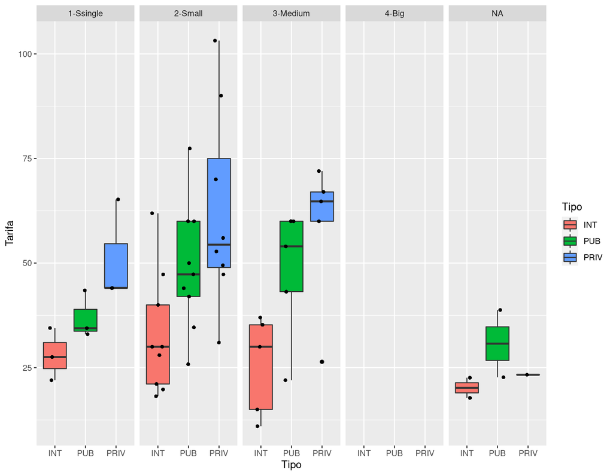

## Correlaciones entre las tarifas por tipos de usuarios

Hay una relación clara entre las tarifas. AUnque podría parecer que deberían estar más relacionadas las tarifas interna y pública, en la práctica lo estan más la pública y la privada.

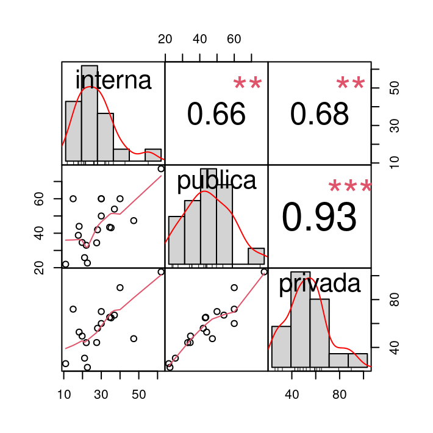